# Biostatistics Homework 3: Immune Response to Seasonal Flu

Sophia Frantz

10/22/2019

# Immune Response to Seasonal Flu Depends on Patient’s Genotype and Flu Strain

2,000 patients were studied to understand how different flu strains affect the immune respinse. Immune response is measured in concentration of interleukin-1B in the blood. The response is determined by the particular flu strain and patient genotype.  
This trend can be visualized in the interaction plot below:

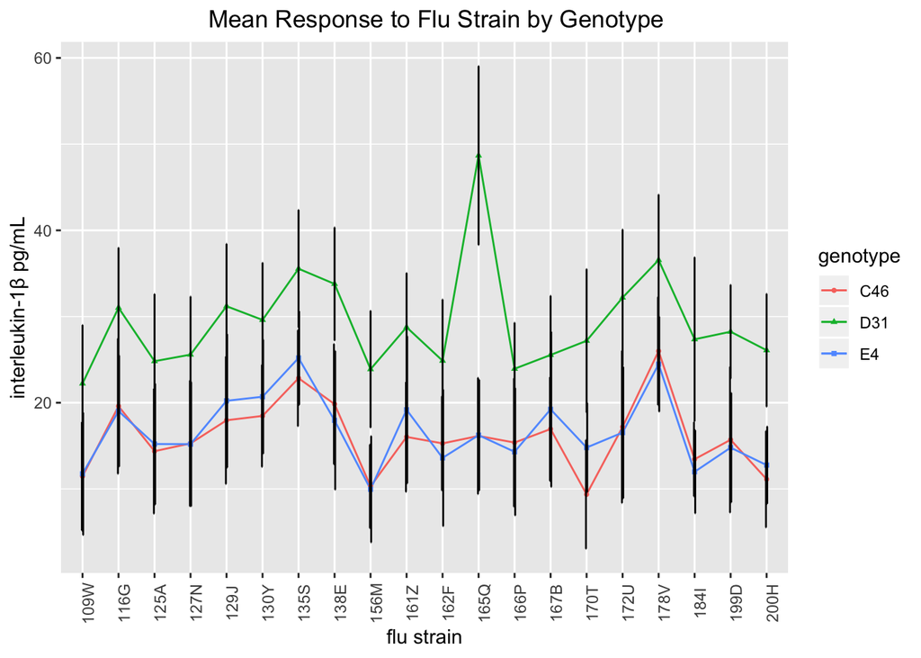

The lines represent the three genotypes studied; each genotype has a different color. On the x-axis in no particular order are the different flu strains. On the y-axis is the immune response measured in pg/mL of interleukin-1B. The mean response within each genotype is shown for each strain, with a different shape representing each genotype mean (see legend). The standard deviation from each mean is depicted with error bars. From the error bars we can see there seems to be a fair amount of variation in immune response within each genotype. However, despite the variation it seems some strains elicit a stronger response, such as strain 178V which produces a high immune response in all 3 genotypes. There also seem to be some interaction effects, meaning the response to the strain depends on the genotype. For example, strain 165Q produces a strong response in genotype D31 but not in the other 2 genotypes. Genotype D31 seems to have a stronger response to all strains.  
These observations will be explicitly tested with a permutation test and an ANOVA test (below).

## Permutation test shows that variation in immune response can be explained by flu strain

As mentioned above, there does seem to be variation in the response to each strain, even within each genotype. We want to know whether the strength of the immune response can be explained by strain. If so, then the variation in the response will be even greater when we disassociate the true responses from the strains through random shuffling. If we see that the variation is greater with this random association of responses and means, this means the true associations do explain the strength of the immune response. In other words, this result would mean the variation within each strain is lower than the overall variation across all strains.  
Since genotype has a large effect on immune response, we want to make sure to shuffle the responses within each genotype. This tests for the effect of strain while controlling for genotype, so that all variables are held constant except for the strain.  
I shuffled the responses to the strains within each genotype and then calculated the standard deviation for each strain. I then calculated the mean of the standard deviation across all strains for each genotype. I then calculated the mean of this mean SD across genotypes. This number represents the mean SD of all strains after shuffling and while controlling for genotype. I saved this value, replicated this process 1000 times, and then plotted the frequency of the values.

If strain determines flu response, then the true standard deviation of the mean response within each strain will be lower than the standard deviations that result from randomly shuffling the response variables. Shown below are the results.

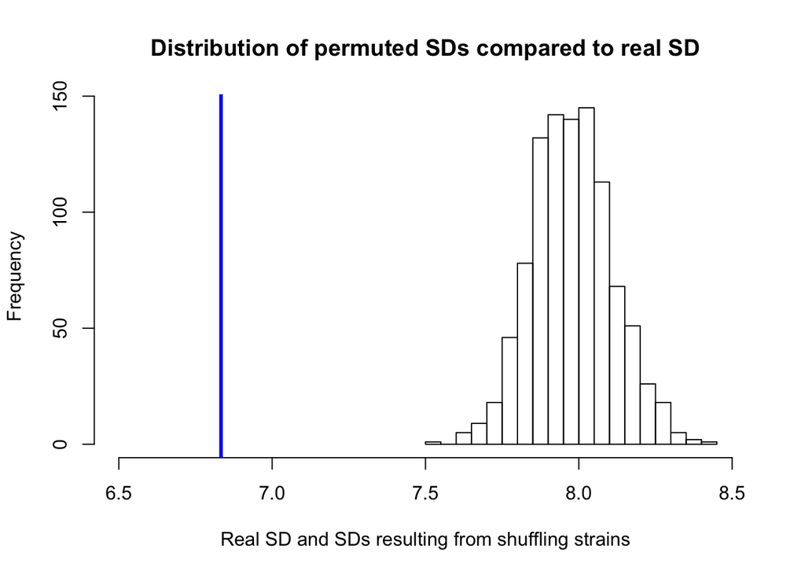

We can see that the true SD shown in blue is lower than the SDs generated from shuffling. In fact, the random shuffling never produced a value as low as the true SD. This means strain helps to determine the reponse to the flu.

## ANOVA test confirms that immune response is determined by genotype, flu strain, and the interaction

Shown below is the formula and results for an ANOVA test for the effects of strain, genotype, and the interaction of strain by genotype.

```r
anova(lm(response ~ strain * genotype, data=fluData))
```

```
## Analysis of Variance Table
##
## Response: response
##                   Df Sum Sq Mean Sq  F value    Pr(>F)
## strain            19  37392  1968.0  41.4027 < 2.2e-16 ***
## genotype           2  60875 30437.6 640.3478 < 2.2e-16 ***
## strain:genotype   38   6061   159.5   3.3557 3.771e-11 ***
## Residuals       1940  92214    47.5
## ---
## Signif. codes:  0 '***' 0.001 '**' 0.01 '*' 0.05 '.' 0.1 ' ' 1
```

All three variables are significant, meaning strain, genotype, and the interaction effect all help to determine the strength of the immune response.

Finally, below is the formula and results for a linear model which tests the effect of each genotype and strain in explaining the variation in the immune response.  
From these results, we can confirm some of our speculations from the interaction plot: Strain 178V significantly affects the immune response. Genotype D31 is significantly different in its response compared to the other two genotypes. The significant interaction effect (strainA1b/165Q:genotypeD31) means the response to this strain depends on whether it is present in genotype D31 or not. This relationship and strainA1b/170T:genotypeD31 are the only 2 significant interaction terms.

```r
summary(lm(response ~ strain * genotype, data=fluData))
```

```
##
## Call:
## lm(formula = response ~ strain * genotype, data = fluData)
##
## Residuals:
##      Min       1Q   Median       3Q      Max
## -21.5873  -4.7342  -0.1221   4.5148  22.0657
##
## Coefficients:
##                            Estimate Std. Error t value Pr(>|t|)
## (Intercept)                 11.4701     0.4875  23.528  < 2e-16 ***
## strainA1b/116G               8.1277     0.9428   8.621  < 2e-16 ***
## strainA1b/125A               2.9074     1.0282   2.828  0.00474 **
## strainA1b/127N               3.8121     1.3127   2.904  0.00372 **
## strainA1b/129J               6.4963     1.3498   4.813 1.60e-06 ***
## strainA1b/130Y               7.0012     1.3911   5.033 5.28e-07 ***
## strainA1b/135S              11.3760     1.3911   8.177 5.18e-16 ***
## strainA1b/138E               8.3699     1.7418   4.805 1.66e-06 ***
## strainA1b/156M              -1.1696     1.5180  -0.770  0.44111
## strainA1b/161Z               4.5652     1.6966   2.691  0.00719 **
## strainA1b/162F               3.8129     1.9733   1.932  0.05348 .
## strainA1b/165Q               4.6786     1.8457   2.535  0.01133 *
## strainA1b/166P               3.9097     1.6551   2.362  0.01827 *
## strainA1b/167B               5.4800     1.9060   2.875  0.00408 **
## strainA1b/170T              -2.0982     2.4858  -0.844  0.39873
## strainA1b/172U               5.7293     2.1351   2.683  0.00735 **
## strainA1b/178V              14.5239     2.0491   7.088 1.90e-12 ***
## strainA1b/184I               1.9800     2.1351   0.927  0.35387
## strainA1b/199D               4.2351     2.2340   1.896  0.05815 .
## strainA1b/200H              -0.3434     2.4858  -0.138  0.89013
## genotypeD31                 10.7585     0.7215  14.911  < 2e-16 ***
## genotypeE4                   0.2821     0.6985   0.404  0.68629
## strainA1b/116G:genotypeD31   0.6676     1.3261   0.503  0.61475
## strainA1b/125A:genotypeD31  -0.3182     1.4432  -0.220  0.82554
## strainA1b/127N:genotypeD31  -0.4591     1.6989  -0.270  0.78702
## strainA1b/129J:genotypeD31   2.4730     1.8609   1.329  0.18403
## strainA1b/130Y:genotypeD31   0.3775     1.8911   0.200  0.84181
## strainA1b/135S:genotypeD31   1.9434     1.9947   0.974  0.33004
## strainA1b/138E:genotypeD31   3.1854     2.1914   1.454  0.14622
## strainA1b/156M:genotypeD31   2.8328     2.3576   1.202  0.22968
```

[output cut: 21 more lines]

```
## strainA1b/165Q:genotypeE4   -0.1941     2.4563  -0.079  0.93702
## strainA1b/166P:genotypeE4   -1.3543     2.1387  -0.633  0.52666
## strainA1b/167B:genotypeE4    2.0012     3.0273   0.661  0.50866
## strainA1b/170T:genotypeE4    5.1467     3.1758   1.621  0.10527
## strainA1b/172U:genotypeE4   -0.9436     3.0216  -0.312  0.75486
## strainA1b/178V:genotypeE4   -1.8047     2.6364  -0.685  0.49372
## strainA1b/184I:genotypeE4   -1.7440     3.4058  -0.512  0.60866
## strainA1b/199D:genotypeE4   -1.1946     3.0923  -0.386  0.69931
## strainA1b/200H:genotypeE4    1.3551     2.9885   0.453  0.65029
## ---
## Signif. codes:  0 '***' 0.001 '**' 0.01 '*' 0.05 '.' 0.1 ' ' 1
##
## Residual standard error: 6.894 on 1940 degrees of freedom
## Multiple R-squared:  0.5308, Adjusted R-squared:  0.5165
## F-statistic:  37.2 on 59 and 1940 DF,  p-value: < 2.2e-16
```